# HW 4 Solution

Abhijit Dasgupta

In this homework you will generate your own R Markdown file, either using the R Markdown templates in RStudio or from scratch. For each question, you will create R chunks which you will populate with code. The code and the results should be visible in the HTML file that you knit the R Markdown to.

The header of the R Markdown file will look like this

```
---
title: "Week 4 assignment"
author: "Your name"
output: html_document
---
```

Each question is 10 points.

### Question 1

We will use the dataset `riskfactors` available in the class data link.

There are two files holding the same data. `riskfactors.rds` stores the data in R-native format, which can be read as `riskfactors <- readRDS('data/riskfactors.rds')` (you can update the path based on where you store the file). The `riskfactors.csv` file can be read using `read_csv`.

```r
riskfactors <- readRDS("data/riskfactors.rds")
```

#### Part a

Draw a summary plot that shows data types and missing data patterns

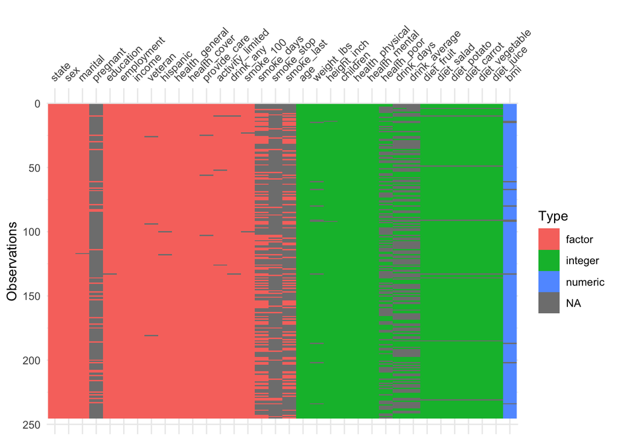

```r
library(visdat)
vis_dat(riskfactors)
```

#### Part b

Draw an upset plot of missing data patterns in this dataset including the top 10 most missing variables.

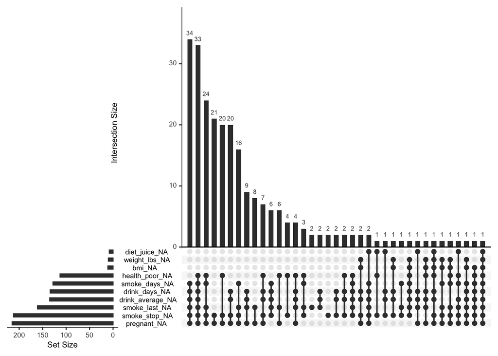

```r
naniar::gg_miss_upset(riskfactors, nsets = 10)
```